# Insurance Expenses Analysis

**Overview**: The data consists of various categorical and numerical features, focusing on insurance expenses. They provide comprehensive insights into various factors that might influence insurance expenses.

**Background**:The data comprises insurance expenses claimed by individuals with various medical-related features. The aim is to provide a deeper understanding of the data distributions and correlations and to possibly estimate insurance expenses.

# Outline

- Data overview
- Exploratory data analysis
- Statistical analysis
- Final insights

# 1. Data overview

- Import libraries
- Set up directories
- Read data and quick data check

```python
import numpy as np
import pandas as pd
import matplotlib.pyplot as plt
import seaborn as sns
import scipy.stats as stats
```

```python
dir = '/insurance/'
```

```python
df0 = pd.read_csv(dir + 'insurance.csv')
```

```python
df0.head()
```

|  | age | sex | bmi | children | smoker | region | expenses |
| --- | --- | --- | --- | --- | --- | --- | --- |
| 0 | 19 | female | 27.9 | 0 | yes | southwest | 16884.92 |
| 1 | 18 | male | 33.8 | 1 | no | southeast | 1725.55 |
| 2 | 28 | male | 33.0 | 3 | no | southeast | 4449.46 |
| 3 | 33 | male | 22.7 | 0 | no | northwest | 21984.47 |
| 4 | 32 | male | 28.9 | 0 | no | northwest | 3866.86 |

```python
df0.info()
```

```
<class 'pandas.core.frame.DataFrame'>
RangeIndex: 1338 entries, 0 to 1337
Data columns (total 7 columns):
 #   Column    Non-Null Count  Dtype
---  ------    --------------  -----
 0   age       1338 non-null   int64
 1   sex       1338 non-null   object
 2   bmi       1338 non-null   float64
 3   children  1338 non-null   int64
 4   smoker    1338 non-null   object
 5   region    1338 non-null   object
 6   expenses  1338 non-null   float64
dtypes: float64(2), int64(2), object(3)
memory usage: 73.3+ KB
```

```python
df0.describe().transpose()
```

|  | count | mean | std | min | 25% | 50% | 75% | max |
| --- | --- | --- | --- | --- | --- | --- | --- | --- |
| age | 1338.0 | 39.207025 | 14.049960 | 18.00 | 27.0000 | 39.00 | 51.000 | 64.00 |
| bmi | 1338.0 | 30.665471 | 6.098382 | 16.00 | 26.3000 | 30.40 | 34.700 | 53.10 |
| children | 1338.0 | 1.094918 | 1.205493 | 0.00 | 0.0000 | 1.00 | 2.000 | 5.00 |
| expenses | 1338.0 | 13270.422414 | 12110.011240 | 1121.87 | 4740.2875 | 9382.03 | 16639.915 | 63770.43 |

```python
df = df0.copy()
```

```python
def age_mapping(x):

    if x < 20: return 15
    elif x < 25: return 20
    elif x < 30: return 25
    elif x < 35: return 30
    elif x < 40: return 35
    elif x < 45: return 40
    elif x < 50: return 45
    elif x < 55: return 50
    elif x < 60: return 55
    else: return 60

df['age_group'] = df['age'].apply(age_mapping)
```

```python
def bmi_mapping(x):
    if x < 25: return 'Healthy weight'
    elif x < 30: return 'Overweight'
    else: return 'Obese'

df['bmi_group'] = df['bmi'].apply(bmi_mapping)
```

```python
df.info()
```

```
<class 'pandas.core.frame.DataFrame'>
RangeIndex: 1338 entries, 0 to 1337
Data columns (total 9 columns):
 #   Column     Non-Null Count  Dtype
---  ------     --------------  -----
 0   age        1338 non-null   int64
 1   sex        1338 non-null   object
 2   bmi        1338 non-null   float64
 3   children   1338 non-null   int64
 4   smoker     1338 non-null   object
 5   region     1338 non-null   object
 6   expenses   1338 non-null   float64
 7   age_group  1338 non-null   int64
 8   bmi_group  1338 non-null   object
dtypes: float64(2), int64(3), object(4)
memory usage: 94.2+ KB
```

# 2. Exploratory data analysis (EDA)

## 2.1 Distributions for categorical and numerical data

A **countplot** and a **histplot** are used to visualize categorical and numerical data respectively.

```python
sns.set_theme()
```

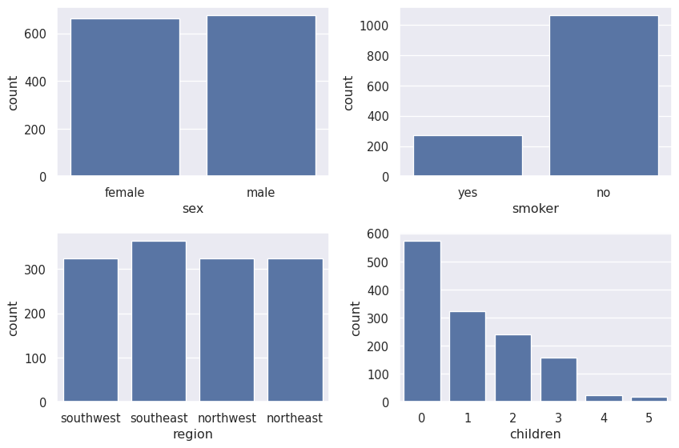

```python
fig, ax = plt.subplots(nrows=2, ncols=2, figsize=(9, 6), dpi=96)
sns.countplot(data=df, x='sex', ax=ax[0][0])
sns.countplot(data=df, x='smoker', ax=ax[0][1])
sns.countplot(data=df, x='region', ax=ax[1][0])
sns.countplot(data=df, x='children', ax=ax[1][1])
fig.tight_layout();
```

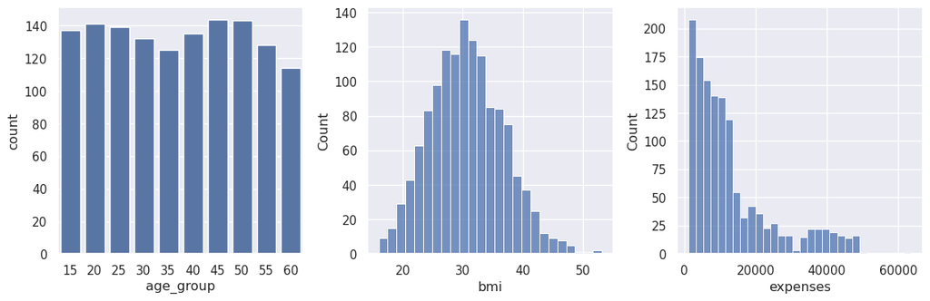

```python
fig, ax = plt.subplots(nrows=1, ncols=3, figsize=(12, 4), dpi=96)
sns.countplot(data=df, x='age_group', ax=ax[0])
sns.histplot(data=df, x='bmi', ax=ax[1])
sns.histplot(data=df, x='expenses', ax=ax[2])
fig.tight_layout();
```

## 2.2 Correlations

A **pairplot** is used to visualize distributions among numerical variables using kde(histogram) and scatter plots. A **heatmap** is used to visualize correlation coefficient among numerical variables.

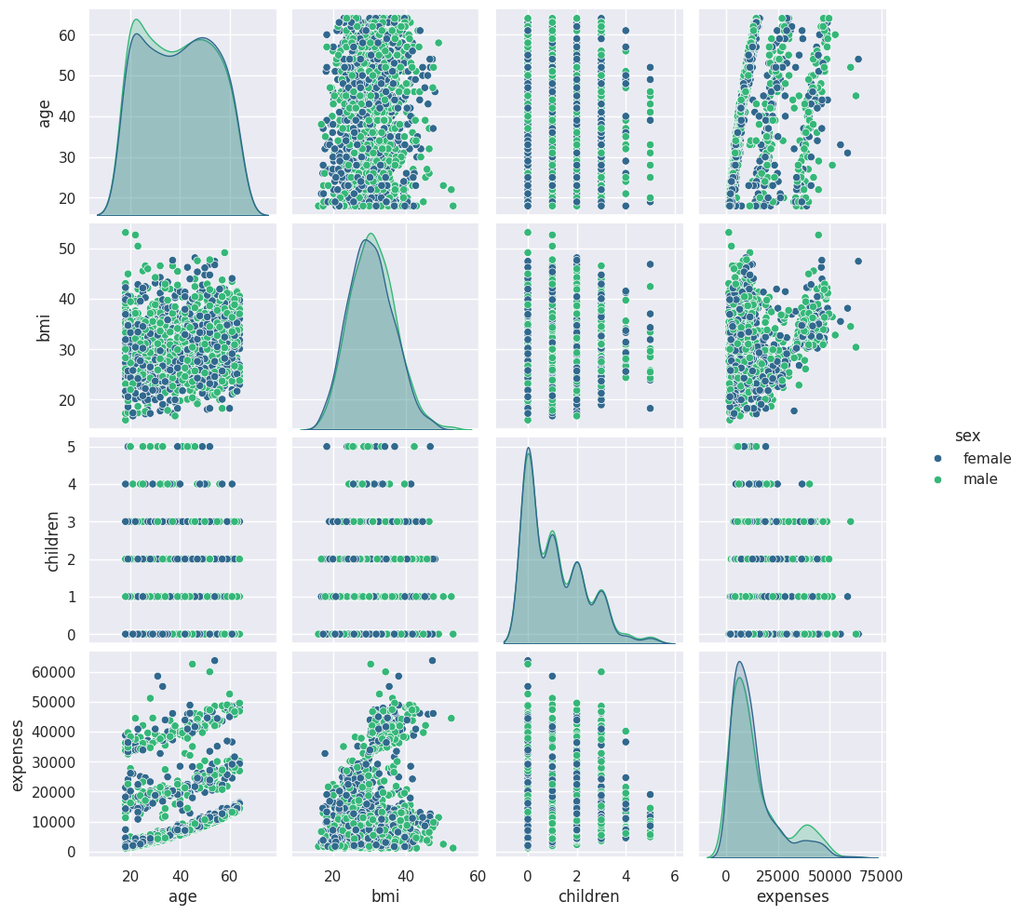

```python
sns.pairplot(df.drop(columns=['age_group', 'bmi_group']), hue='sex', palette='viridis');
```

```python
g = df0.copy()
g = pd.get_dummies(g, drop_first=True)
g.head()
```

|  | age | bmi | children | expenses | sex_male | smoker_yes | region_northwest | region_southeast | region_southwest |
| --- | --- | --- | --- | --- | --- | --- | --- | --- | --- |
| 0 | 19 | 27.9 | 0 | 16884.92 | False | True | False | False | True |
| 1 | 18 | 33.8 | 1 | 1725.55 | True | False | False | True | False |
| 2 | 28 | 33.0 | 3 | 4449.46 | True | False | False | True | False |
| 3 | 33 | 22.7 | 0 | 21984.47 | True | False | True | False | False |
| 4 | 32 | 28.9 | 0 | 3866.86 | True | False | True | False | False |

```python
corr = g.corr()
corr
```

|  | age | bmi | children | expenses | sex_male | smoker_yes | region_northwest | region_southeast | region_southwest |
| --- | --- | --- | --- | --- | --- | --- | --- | --- | --- |
| age | 1.000000 | 0.109341 | 0.042469 | 0.299008 | -0.020856 | -0.025019 | -0.000407 | -0.011642 | 0.010016 |
| bmi | 0.109341 | 1.000000 | 0.012645 | 0.198576 | 0.046380 | 0.003968 | -0.135992 | 0.270144 | -0.006398 |
| children | 0.042469 | 0.012645 | 1.000000 | 0.067998 | 0.017163 | 0.007673 | 0.024806 | -0.023066 | 0.021914 |
| expenses | 0.299008 | 0.198576 | 0.067998 | 1.000000 | 0.057292 | 0.787251 | -0.039905 | 0.073982 | -0.043210 |
| sex_male | -0.020856 | 0.046380 | 0.017163 | 0.057292 | 1.000000 | 0.076185 | -0.011156 | 0.017117 | -0.004184 |
| smoker_yes | -0.025019 | 0.003968 | 0.007673 | 0.787251 | 0.076185 | 1.000000 | -0.036945 | 0.068498 | -0.036945 |
| region_northwest | -0.000407 | -0.135992 | 0.024806 | -0.039905 | -0.011156 | -0.036945 | 1.000000 | -0.346265 | -0.320829 |
| region_southeast | -0.011642 | 0.270144 | -0.023066 | 0.073982 | 0.017117 | 0.068498 | -0.346265 | 1.000000 | -0.346265 |
| region_southwest | 0.010016 | -0.006398 | 0.021914 | -0.043210 | -0.004184 | -0.036945 | -0.320829 | -0.346265 | 1.000000 |

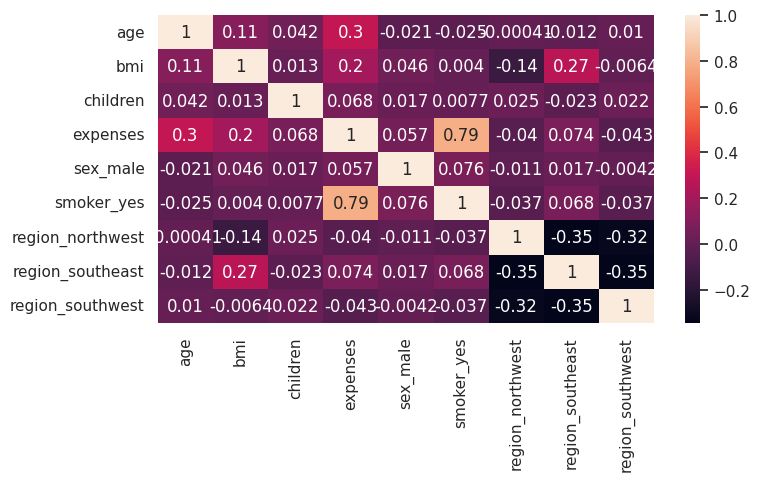

```python
plt.figure(figsize=(8, 4))
sns.heatmap(corr, annot=True);
```

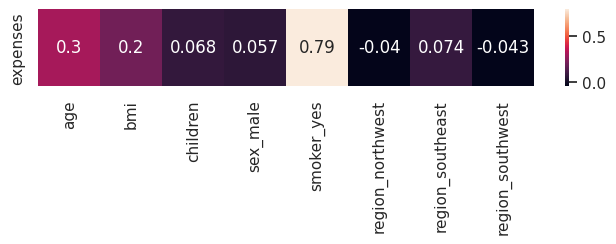

```python
plt.figure(figsize=(8, 1))
sns.heatmap(corr[corr['expenses']<1][['expenses']].transpose(), annot=True);
```

## 2.3 Expenses vs. others

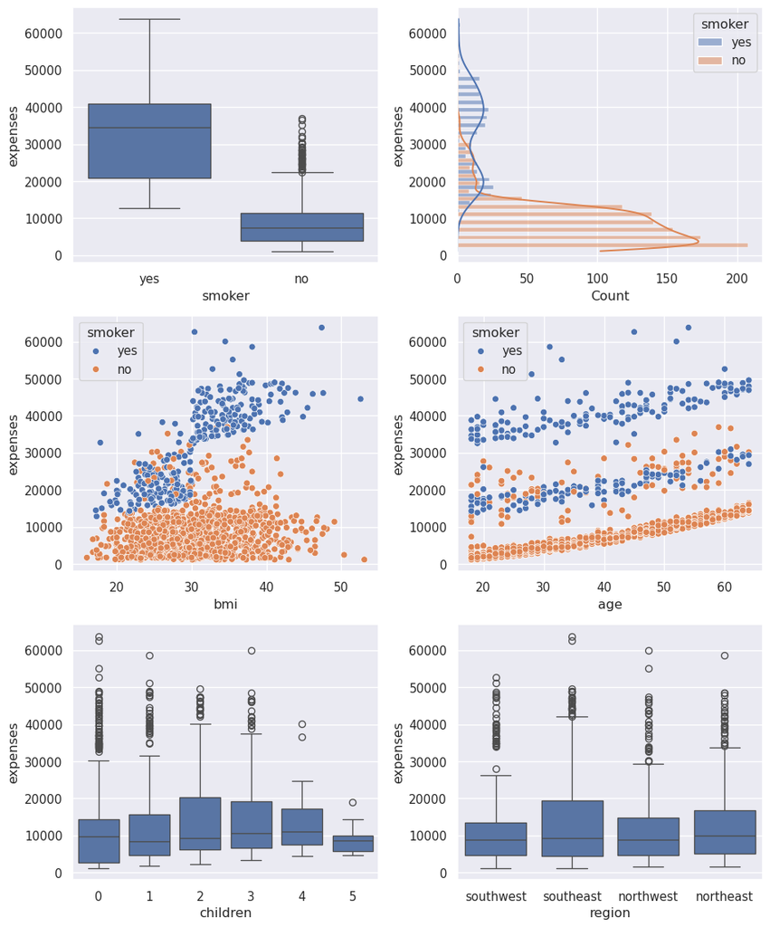

```python
fig, ax = plt.subplots(nrows=3, ncols=2, figsize=(10, 12), dpi=96)
sns.boxplot(data=df, x='smoker', y='expenses', ax=ax[0][0])
sns.histplot(data=df, y='expenses', hue='smoker', multiple='dodge', kde=True, ax=ax[0][1])
sns.scatterplot(data=df, x='bmi', y='expenses', hue='smoker', ax=ax[1][0])
sns.scatterplot(data=df, x='age', y='expenses', hue='smoker', ax=ax[1][1])
sns.boxplot(data=df, x='children', y='expenses', ax=ax[2][0])
sns.boxplot(data=df, x='region', y='expenses', ax=ax[2][1])
fig.tight_layout();
```

## 2.4 Smokers vs. Non-smokers and Male vs. Famale

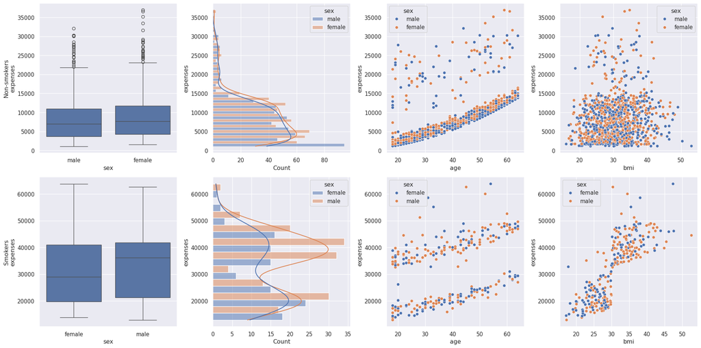

```python
fig, ax = plt.subplots(nrows=2, ncols=4, figsize=(20, 10), dpi=96)
sns.boxplot(data=df[df['smoker']=='no'], x='sex', y='expenses', ax=ax[0][0])
sns.histplot(data=df[df['smoker']=='no'], y='expenses', hue='sex', multiple='dodge', kde=True, ax=ax[0][1])
ax[0][0].set(ylabel='Non-smokers\nexpenses')
sns.scatterplot(data=df[df['smoker']=='no'], x='age', y='expenses', hue='sex', ax=ax[0][2])
sns.scatterplot(data=df[df['smoker']=='no'], x='bmi', y='expenses', hue='sex', ax=ax[0][3])

sns.boxplot(data=df[df['smoker']=='yes'], x='sex', y='expenses', ax=ax[1][0])
sns.histplot(data=df[df['smoker']=='yes'], y='expenses', hue='sex', multiple='dodge', kde=True, ax=ax[1][1])
ax[1][0].set(ylabel='Smokers\nexpenses')
sns.scatterplot(data=df[df['smoker']=='yes'], x='age', y='expenses', hue='sex', ax=ax[1][2])
sns.scatterplot(data=df[df['smoker']=='yes'], x='bmi', y='expenses', hue='sex', ax=ax[1][3])
fig.tight_layout()
```

## 2.5 BMI vs. others

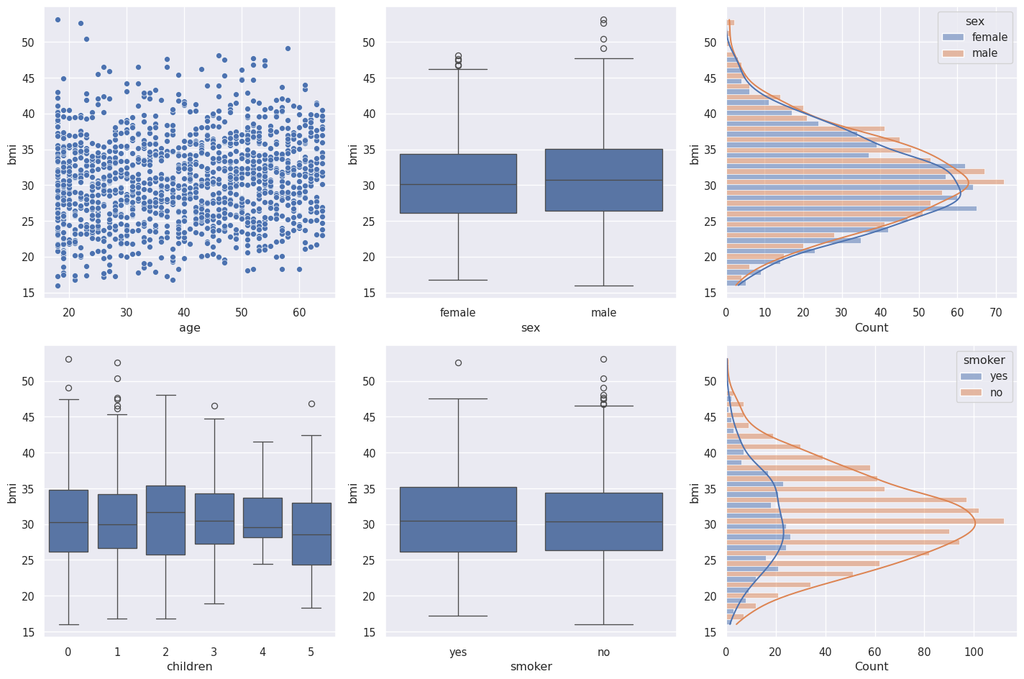

```python
fig, ax = plt.subplots(nrows=2, ncols=3, figsize=(15, 10), dpi=96)
sns.scatterplot(data=df, x='age', y='bmi', ax=ax[0][0])
sns.boxplot(data=df, y='bmi', x='sex', ax=ax[0][1])
sns.histplot(data=df, y='bmi', hue='sex', multiple='dodge', kde=True, ax=ax[0][2])

sns.boxplot(data=df, x='children', y='bmi', ax=ax[1][0])
sns.boxplot(data=df, y='bmi', x='smoker', ax=ax[1][1])
sns.histplot(data=df, y='bmi', hue='smoker', multiple='dodge', kde=True, ax=ax[1][2])

fig.tight_layout();
```

## 2.6 Region vs. others

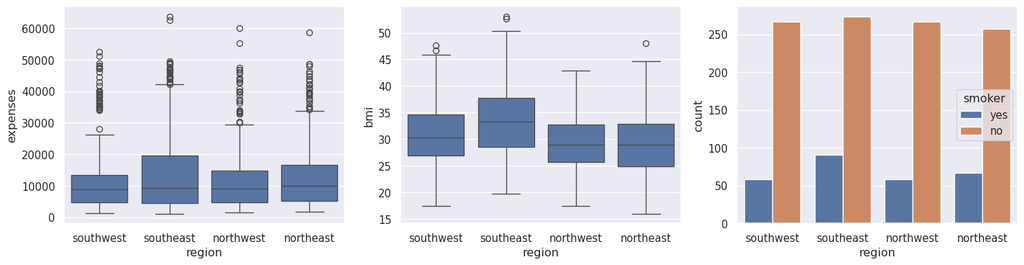

```python
fig, ax = plt.subplots(nrows=1, ncols=3, figsize=(15, 4), dpi=96)
sns.boxplot(data=df, x='region', y='expenses', ax=ax[0])
sns.boxplot(data=df, x='region', y='bmi', ax=ax[1])
sns.countplot(data=df, x='region', hue='smoker', ax=ax[2])
sns.move_legend(ax[2], 'center right')
fig.tight_layout()
```

# 3. Statistical analysis: Hypothesis testing

- Step1. State the null and alternative hypotheses.
- Step2. Set the significance level, alpha.
- Step3. Identify the RV and the distribution for the test.
- Step4. Calculate the test statistics & the p-value.
- Step5. Reject or do not reject the null hypothesis.

```python
def test_conclusion(ho, ha, test_statistic, pval, alpha=0.05):

    print('Test statistic = {:.2f}, p-value = {:.8f}'.format(test_statistic, pval))

    if pval < alpha:
        print(f'Reject the null hypothesis as p-value is less than alpha, {alpha}.')
        print(f'At the {alpha*100:.1f}% level of significance, there is sufficient evidence to conclude that \n{ha}.')
    else:
        print(f'Accept the null hypothesis as p-value is greater than alpha, {alpha}.')
        print(f'At the {alpha*100:.1f}% level of significance, there is not sufficient evidence to conclude that \n{ha}.')

    return
```

### 3.1 [T-test] The insurance expenses for smokers are greater than those for non-smokers.

- Step1: Hypotheses \begin{align} H_o: \mu_1 = \mu_2\\ H_a: \mu_1 > \mu_2 \end{align}
- Step2: $α = 0.05$
- Step3: $\bar{X_1} - \bar{X_2}$ with student's t distribution because the population standard deviations are unknown.
- Step4: Right tailed p-value = $P(T>t)$
- Step5: Conclusion.

```python
ho = 'the average insurance expenses for smokers are same with those for non-smokers'
ha = 'the average insurance expenses for smokers are greater than those for non-smokers'
```

```python
df['smoker'].value_counts()
```

```
smoker
no     1064
yes     274
Name: count, dtype: int64
```

```python
df1 = df[df['smoker']=='yes']
df1[['expenses']].describe()
```

|  | expenses |
| --- | --- |
| count | 274.000000 |
| mean | 32050.231971 |
| std | 11541.547338 |
| min | 12829.460000 |
| 25% | 20826.245000 |
| 50% | 34456.350000 |
| 75% | 41019.205000 |
| max | 63770.430000 |

```python
df2 = df[df['smoker']=='no']
selected_rows = np.random.randint(0, df2.shape[0], size=df1.shape[0])
df2 = df2.iloc[selected_rows]
df2[['expenses']].describe()
```

|  | expenses |
| --- | --- |
| count | 274.000000 |
| mean | 8338.754124 |
| std | 5795.619352 |
| min | 1131.510000 |
| 25% | 3987.840000 |
| 50% | 7199.285000 |
| 75% | 11339.757500 |
| max | 31620.000000 |

```python
test_statistic, pval = stats.ttest_ind(df1['expenses'], df2['expenses'])
pval = pval/2
```

```python
test_conclusion(ho, ha, test_statistic, pval)
```

```
Test statistic = 30.39, p-value = 0.00000000
Reject the null hypothesis as p-value is less than alpha, 0.05.
At the 5.0% level of significance, there is sufficient evidence to conclude that
the average insurance expenses for smokers are greater than those for non-smokers.
```

### 3.2 [T-test] The BMIs for male and female are different.

- Step1: Hypotheses \begin{align} H_o: \mu_1 = \mu_2\\ H_a: \mu_1 \neq \mu_2 \end{align}
- Step2: $α = 0.05$
- Step3: $\bar{X_1} - \bar{X_2}$ with student's t distribution because the population standard deviations are unknown.
- Step4: Both tailed p-value = $P(|T|>t)$
- Step5: Conclusion.

```python
ho = 'the average BMIs for males and females are same'
ha = 'the average BMIs for males and females are different'
```

```python
df['sex'].value_counts()
```

```
sex
male      676
female    662
Name: count, dtype: int64
```

```python
df1 = df[df['sex']=='male']
df1[['bmi']].describe()
```

|  | bmi |
| --- | --- |
| count | 676.000000 |
| mean | 30.945266 |
| std | 6.140346 |
| min | 16.000000 |
| 25% | 26.400000 |
| 50% | 30.700000 |
| 75% | 35.025000 |
| max | 53.100000 |

```python
df2 = df[df['sex']=='female']
df2['bmi'].describe()
```

```
count    662.000000
mean      30.379758
std        6.046508
min       16.800000
25%       26.100000
50%       30.100000
75%       34.300000
max       48.100000
Name: bmi, dtype: float64
```

```python
test_statistic, pval = stats.ttest_ind(df1['bmi'], df2['bmi'])
```

```python
test_conclusion(ho, ha, test_statistic, pval)
```

```
Test statistic = 1.70, p-value = 0.08991357
Accept the null hypothesis as p-value is greater than alpha, 0.05.
At the 5.0% level of significance, there is not sufficient evidence to conclude that
the average BMIs for males and females are different.
```

### 3.3 [One-way ANOVA] The BMIs of women with 0, 1, and 2 children are different.

- Step1: Hypotheses \begin{align} H_o: \mu_1 = \mu_2 = \mu_3\\ H_a: \mu_i \neq \mu_j \text{ for any } i \neq j \end{align}
- Step2: $α = 0.05$
- Step3: $F = \frac{MS_{between}}{MS_{within}} $ with one-way ANOVA because of the equality of three+ population means through sample variances.
- Step4: Right tailed p-value = $P(F>f)$
- Step5: Conclusion.

```python
ho = 'the average BMIs of women with 0, 1 and 2 children are same'
ha = 'the average BMIs of women with 0, 1 and 2 children are different'
```

```python
df[df['sex']=='female']['children'].value_counts()
```

```
children
0    289
1    158
2    119
3     77
4     11
5      8
Name: count, dtype: int64
```

```python
df1 = df[(df['sex']=='female')&(df['children']==0)]
df1[['bmi']].describe()
```

|  | bmi |
| --- | --- |
| count | 289.000000 |
| mean | 30.364360 |
| std | 5.968564 |
| min | 17.300000 |
| 25% | 26.200000 |
| 50% | 29.900000 |
| 75% | 34.600000 |
| max | 47.400000 |

```python
df2 = df[(df['sex']=='female')&(df['children']==1)]
df2[['bmi']].describe()
```

|  | bmi |
| --- | --- |
| count | 158.000000 |
| mean | 30.053165 |
| std | 5.785306 |
| min | 16.800000 |
| 25% | 25.950000 |
| 50% | 29.550000 |
| 75% | 33.950000 |
| max | 46.100000 |

```python
df3 = df[(df['sex']=='female')&(df['children']==2)]
df3[['bmi']].describe()
```

|  | bmi |
| --- | --- |
| count | 119.000000 |
| mean | 30.651261 |
| std | 6.627304 |
| min | 17.200000 |
| 25% | 25.750000 |
| 50% | 31.300000 |
| 75% | 34.750000 |
| max | 48.100000 |

```python
test_statistic, pval = stats.f_oneway(df1['bmi'], df2['bmi'], df3['bmi'])
```

```python
test_conclusion(ho, ha, test_statistic, pval)
```

```
Test statistic = 0.34, p-value = 0.71483351
Accept the null hypothesis as p-value is greater than alpha, 0.05.
At the 5.0% level of significance, there is not sufficient evidence to conclude that
the average BMIs of women with 0, 1 and 2 children are different.
```

### 3.4 [One-way ANOVA] The BMIs across different regions are different.

- Step1: Hypotheses \begin{align} H_o: \mu_1 = \mu_2 = \mu_3 = \mu_4\\ H_a: \mu_i \neq \mu_j \text{ for any } i \neq j \end{align}
- Step2: $α = 0.05$
- Step3: $F = \frac{MS_{between}}{MS_{within}} $ with one-way ANOVA because of the equality of three+ population means through sample variances.
- Step4: Right tailed p-value = $P(F>f)$
- Step5: Conclusion.

```python
ho = 'the average BMIs of the four different regions (SE, SW, NE, NW) are same'
ha = 'the average BMIs of the four different regions (SE, SW, NE, NW) are not same'
```

```python
df['region'].value_counts()
```

```
region
southeast    364
southwest    325
northwest    325
northeast    324
Name: count, dtype: int64
```

```python
df1 = df[df['region']=='southeast']
df1[['bmi']].describe()
```

|  | bmi |
| --- | --- |
| count | 364.000000 |
| mean | 33.359341 |
| std | 6.478891 |
| min | 19.800000 |
| 25% | 28.575000 |
| 50% | 33.300000 |
| 75% | 37.800000 |
| max | 53.100000 |

```python
df2 = df[df['region']=='southwest']
df2[['bmi']].describe()
```

|  | bmi |
| --- | --- |
| count | 325.000000 |
| mean | 30.596615 |
| std | 5.691836 |
| min | 17.400000 |
| 25% | 26.900000 |
| 50% | 30.300000 |
| 75% | 34.600000 |
| max | 47.600000 |

```python
df3 = df[df['region']=='northeast']
df3[['bmi']].describe()
```

|  | bmi |
| --- | --- |
| count | 324.000000 |
| mean | 29.176235 |
| std | 5.936847 |
| min | 16.000000 |
| 25% | 24.875000 |
| 50% | 28.900000 |
| 75% | 32.925000 |
| max | 48.100000 |

```python
df4 = df[df['region']=='northwest']
df4[['bmi']].describe()
```

|  | bmi |
| --- | --- |
| count | 325.000000 |
| mean | 29.201846 |
| std | 5.136140 |
| min | 17.400000 |
| 25% | 25.700000 |
| 50% | 28.900000 |
| 75% | 32.800000 |
| max | 42.900000 |

```python
test_statistic, pval = stats.f_oneway(df1['bmi'], df2['bmi'], df3['bmi'], df4['bmi'])
```

```python
test_conclusion(ho, ha, test_statistic, pval)
```

```
Test statistic = 39.51, p-value = 0.00000000
Reject the null hypothesis as p-value is less than alpha, 0.05.
At the 5.0% level of significance, there is sufficient evidence to conclude that
the average BMIs of the four different regions (SE, SW, NE, NW) are not same.
```

### 3.5 [Chi-square test] The distributions(proportions) of smokers and non-smokers across different regions are different.

- Step1: Hypotheses \begin{align} H_o: \text{The distribution of smokers and non-smokers across different regions are same.}\\ H_a: \text{The distribution of smokers and non-smokers across different regions are not same.} \end{align}
- Step2: $α = 0.05$
- Step3: $K = \sum_{k} \frac{{(O-E)}^2}{E}$ with Chi-square homogeneity test because two different categorical variables, smoker/non-smoker and different regions.
- Step4: Right tailed p-value = $P(K>k)$
- Step5: Conclusion.

```python
ho = 'the distribution of smokers and non-smokers across different regions are same'
ha = 'the distribution of smokers and non-smokers across different regions are different'
```

```python
observed = pd.crosstab(df['region'], df['smoker'])
observed
```

| smoker region | no | yes |
| --- | --- | --- |
| northeast | 257 | 67 |
| northwest | 267 | 58 |
| southeast | 273 | 91 |
| southwest | 267 | 58 |

```python
chi2, pval, dof, expected = stats.chi2_contingency(observed, correction=False)
```

```python
observed
```

| smoker region | no | yes |
| --- | --- | --- |
| northeast | 257 | 67 |
| northwest | 267 | 58 |
| southeast | 273 | 91 |
| southwest | 267 | 58 |

```python
dof
```

```
3
```

```python
expected = pd.DataFrame(expected)
expected
```

|  | 0 | 1 |
| --- | --- | --- |
| 0 | 257.650224 | 66.349776 |
| 1 | 258.445441 | 66.554559 |
| 2 | 289.458894 | 74.541106 |
| 3 | 258.445441 | 66.554559 |

```python
test_conclusion(ho, ha, chi2, pval)
```

```
Test statistic = 7.34, p-value = 0.06171955
Accept the null hypothesis as p-value is greater than alpha, 0.05.
At the 5.0% level of significance, there is not sufficient evidence to conclude that
the distribution of smokers and non-smokers across different regions are different.
```

### 3.6 [T-test] The correlation coefficient

#### 3.6.1 The correlation coefficient of BMI and insurance expenses for smokers are not 0.

- Step1: Hypotheses \begin{align} H_o: \rho = 0\\ H_a: \rho \neq 0 \end{align}
- Step2: $α = 0.05$
- Step3: $R$ (correlation coefficient of BMI and insurance expenses for smokers) with student's t distribution because the population standard deviations are unknown.
- Step4: Both tailed p-value = $P(|T|>t)$
- Step5: Conclusion.

```python
ho = 'the correlation coefficient of BMI and insurance expenses for smokers is zero'
ha = 'the correlation coefficient of BMI and insurance expenses for smokers is non-zero'
```

```python
df_smokers = df[df['smoker']=='yes']
df_smokers[['bmi', 'expenses']].describe()
```

|  | bmi | expenses |
| --- | --- | --- |
| count | 274.000000 | 274.000000 |
| mean | 30.713139 | 32050.231971 |
| std | 6.320840 | 11541.547338 |
| min | 17.200000 | 12829.460000 |
| 25% | 26.100000 | 20826.245000 |
| 50% | 30.450000 | 34456.350000 |
| 75% | 35.200000 | 41019.205000 |
| max | 52.600000 | 63770.430000 |

```python
test_statistic, pval = stats.pearsonr(df_smokers['bmi'], df_smokers['expenses'])
```

```python
test_conclusion(ho, ha, test_statistic, pval)
```

```
Test statistic = 0.81, p-value = 0.00000000
Reject the null hypothesis as p-value is less than alpha, 0.05.
At the 5.0% level of significance, there is sufficient evidence to conclude that
the correlation coefficient of BMI and insurance expenses for smokers is non-zero.
```

#### 3.6.2 The correlation coefficient of BMI and insurance expenses for non-smokers are 0.

- Step1: Hypotheses \begin{align} H_o: \rho = 0\\ H_a: \rho \neq 0 \end{align}
- Step2: $α = 0.05$
- Step3: $R$ (correlation coefficient of BMI and insurance expenses for non-smokers) with student's t distribution because the population standard deviations are unknown.
- Step4: Both tailed p-value = $P(|T|>t)$
- Step5: Conclusion.

```python
ho = 'the correlation coefficient of BMI and insurance expenses for non-smokers is zero'
ha = 'the correlation coefficient of BMI and insurance expenses for non-smokers is non-zero'
```

```python
df_nonsmokers = df[df['smoker']=='no']
df_nonsmokers[['bmi', 'expenses']].describe()
```

|  | bmi | expenses |
| --- | --- | --- |
| count | 1064.000000 | 1064.000000 |
| mean | 30.653195 | 8434.268449 |
| std | 6.042763 | 5993.781756 |
| min | 16.000000 | 1121.870000 |
| 25% | 26.300000 | 3986.442500 |
| 50% | 30.350000 | 7345.405000 |
| 75% | 34.400000 | 11362.890000 |
| max | 53.100000 | 36910.610000 |

```python
test_statistic, pval = stats.pearsonr(df_nonsmokers['bmi'], df_nonsmokers['expenses'])
```

```python
test_conclusion(ho, ha, test_statistic, pval)
```

```
Test statistic = 0.08, p-value = 0.00615854
Reject the null hypothesis as p-value is less than alpha, 0.05.
At the 5.0% level of significance, there is sufficient evidence to conclude that
the correlation coefficient of BMI and insurance expenses for non-smokers is non-zero.
```

## Results

These results show significant associations of insurance expenses with smoking and BMI for both smokers and nonsmoker, and of BMI with regions, while showing no significant associations of BMI with sex and the number of children, and of the proportions of smoking with regions.

# 4. Final Insights

Various exploratory data analysis and statistical analysis using t-tests, one-way ANOVA tests and chi-square tests are conducted to reveal the relationships among seven categorical and numerical variables.

## **Recommendations**

- **Stop smoking** and **control weight**: In order to reduce medical expenses as a beneficient and as a insurance company, people are strongly encouraged to stop smoking and to control their weight.

## **Future research**

- Quantitative studies on regions: Conduct further research on what can represent a region which influences on bmi and potentially medical expenses.
- Qualitative and quantitative studies on other possible positive factors: Research other factors that can positively impact on medical expenses such as exercises, diet, and mental health.

## **Conclusion**

These insights and recommendations aim to contribute to the in-depth understanding of relationships among various medical-related attributes, ultimately to reduce medical expenses and enhance well-being.